# QK Exercises

Kiffer et al. (2015) were interested in the nutritional value of leaves from native and introduced trees to “shredders” – invertebrate larvae in streams that help to break down organic material. They focused on one shredder species, the caddisfly *Triplectides gracilis* and its relationship between four native species and the blue gum *Eucalyptus globulus*, an introduced species grown in plantations. They exposed individual caddisflies to one of these species, and recorded their growth; their Figure 1 shows the experimental setup. They measured the tibial length of each larva at weekly intervals, and used a conversion equation to estimate the animal’s biomass at this time.

### Preliminaries

First, load the required packages

Get data file

```r
kiffer <- read.csv("data/kiffer_growth.csv")
set_sum_contrasts()
```

```
setting contr.sum globally: options(contrasts=c('contr.sum', 'contr.poly'))
```

```r
# Start by treating week as continuous predictor
kiffer$subject <- factor(kiffer$subject)
kiffer_na <-na.omit(kiffer)
```

```r
#Deprecated code using gather; replaced by chunk with pivot_longer below
kiffer1 <- gather(kiffer, week, growth, week1:week5, factor_key=FALSE)
kiffer1$weekno <- revalue(kiffer1$week, c("week1"="1", "week2"="2", "week3"="3", "week4"="4", "week5"="5"))
kiffer1$week <- factor(kiffer1$week, ordered= TRUE)
class(kiffer1$weekno)
kiffer1_na<-gather(kiffer_na, week, growth, week1:week5, factor_key=FALSE)
kiffer1_na$weekno <- revalue(kiffer1_na$week, c("week1"="1", "week2"="2", "week3"="3", "week4"="4", "week5"="5"))
kiffer1_na$week <- factor(kiffer1_na$week, ordered= TRUE)
class(kiffer1_na$weekno)
```

```r
kiffer1 <-  pivot_longer(kiffer,
    cols = starts_with("week"),
    names_to = "weekno",
    names_prefix = "week",
    names_transform = list(weekno = as.integer),
    values_to = "growth",
    values_drop_na = TRUE,
  )
head(kiffer1)
```

| subject | species | weekno | growth |
| --- | --- | --- | --- |
| 1 | Styrax pohlii | 1 | 0.04 |
| 1 | Styrax pohlii | 2 | -0.02 |
| 1 | Styrax pohlii | 3 | 0.02 |
| 1 | Styrax pohlii | 4 | -0.62 |
| 1 | Styrax pohlii | 5 | -0.95 |
| 2 | Styrax pohlii | 1 | 0.03 |

```r
kiffer1_na <-  pivot_longer(kiffer_na,
    cols = starts_with("week"),
    names_to = "weekno",
    names_prefix = "week",
    names_transform = list(weekno = as.integer),
    values_to = "growth",
    values_drop_na = TRUE,
  )
```

# Model fitting

Run simple OLS and REML models including species*week

```r
kiffer1.aov <- aov(growth~species*weekno+Error(subject), kiffer1)
summary(kiffer1.aov)
```

```
Error: subject
               Df Sum Sq Mean Sq F value   Pr(>F)
species         4 305.12   76.28  31.222 7.34e-16 ***
weekno          1   1.53    1.53   0.626    0.431
species:weekno  4   8.08    2.02   0.827    0.512
Residuals      83 202.78    2.44
---
Signif. codes:  0 ‘***’ 0.001 ‘**’ 0.01 ‘*’ 0.05 ‘.’ 0.1 ‘ ’ 1

Error: Within
                Df Sum Sq Mean Sq F value Pr(>F)
weekno           1  47.88   47.88  154.45 <2e-16 ***
species:weekno   4  56.46   14.11   45.53 <2e-16 ***
Residuals      305  94.55    0.31
---
Signif. codes:  0 ‘***’ 0.001 ‘**’ 0.01 ‘*’ 0.05 ‘.’ 0.1 ‘ ’ 1
```

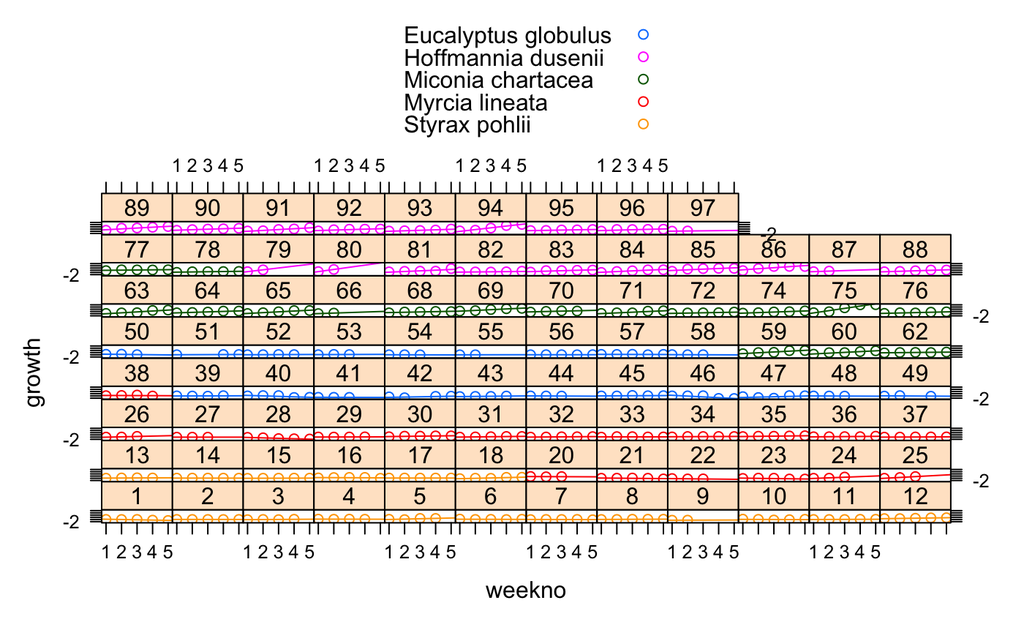

```r
 xyplot(growth~weekno|subject, groups=species, type=c("p","r"), auto.key=T, kiffer1)
```

```r
kiffer1.lmer <- lmer(growth~species*weekno+(weekno|subject), REML=TRUE, kiffer1)
#Second just random intercepts with REML
kiffer2.lmer <- lmer(growth~species*weekno+(1|subject), REML=TRUE, kiffer1)
# Test random slopes term
rand(kiffer1.lmer)
```

```
ANOVA-like table for random-effects: Single term deletions

Model:
growth ~ species + weekno + (weekno | subject) + species:weekno
                             npar  logLik    AIC    LRT Df Pr(>Chisq)
<none>                         14 -346.69 721.39
weekno in (weekno | subject)   12 -439.03 902.06 184.68  2  < 2.2e-16 ***
---
Signif. codes:  0 ‘***’ 0.001 ‘**’ 0.01 ‘*’ 0.05 ‘.’ 0.1 ‘ ’ 1
```

```r
anova(kiffer2.lmer,kiffer1.lmer)
```

```
refitting model(s) with ML (instead of REML)
```

```
Data: kiffer1
Models:
kiffer2.lmer: growth ~ species * weekno + (1 | subject)
kiffer1.lmer: growth ~ species * weekno + (weekno | subject)
             npar    AIC    BIC  logLik deviance  Chisq Df Pr(>Chisq)
kiffer2.lmer   12 865.26 913.25 -420.63   841.26
kiffer1.lmer   14 686.54 742.53 -329.27   658.54 182.72  2  < 2.2e-16 ***
---
Signif. codes:  0 ‘***’ 0.001 ‘**’ 0.01 ‘*’ 0.05 ‘.’ 0.1 ‘ ’ 1
```

Run linear mixed model

```r
kiffer1.mix <- mixed(growth~species*weekno+(weekno|subject), test_intercept=TRUE, kiffer1)
kiffer1.mix
summary(kiffer1.lmer, ddf="Kenward-Roger")
anova(kiffer1.lmer, ddf="Kenward-Roger")
```

[output not shown]

### Now run with time as categorical predictor

```r
#Run as simple split-plot with polynomial contrasts
kiffer1$weekno<-as.factor(kiffer1$weekno)
kiffer2.aov <- aov(growth~species*weekno+Error(subject/weekno), kiffer1)
summary(kiffer2.aov)
```

```
Error: subject
               Df Sum Sq Mean Sq F value   Pr(>F)
species         4 305.12   76.28  29.518 6.97e-15 ***
weekno          4   9.29    2.32   0.899    0.469
species:weekno  7   4.11    0.59   0.227    0.978
Residuals      77 198.99    2.58
---
Signif. codes:  0 ‘***’ 0.001 ‘**’ 0.01 ‘*’ 0.05 ‘.’ 0.1 ‘ ’ 1

Error: subject:weekno
                Df Sum Sq Mean Sq F value Pr(>F)
weekno           4  48.06  12.015   37.91 <2e-16 ***
species:weekno  16  58.92   3.683   11.62 <2e-16 ***
Residuals      290  91.90   0.317
---
Signif. codes:  0 ‘***’ 0.001 ‘**’ 0.01 ‘*’ 0.05 ‘.’ 0.1 ‘ ’ 1
```

```r
summary(kiffer2.aov, split=list(weekno=list(linear=1, quadratic=2, cubic=3)))
```

```
Error: subject
                            Df Sum Sq Mean Sq F value   Pr(>F)
species                      4 305.12   76.28  29.518 6.97e-15 ***
weekno                       4   9.29    2.32   0.899   0.4690
  weekno: linear             1   1.04    1.04   0.404   0.5271
  weekno: quadratic          1   0.24    0.24   0.092   0.7627
  weekno: cubic              1   7.89    7.89   3.051   0.0847 .
species:weekno               7   4.11    0.59   0.227   0.9776
  species:weekno: linear     4   2.50    0.62   0.241   0.9140
  species:weekno: quadratic  0   0.00
  species:weekno: cubic      2   1.45    0.72   0.280   0.7566
Residuals                   77 198.99    2.58
---
Signif. codes:  0 ‘***’ 0.001 ‘**’ 0.01 ‘*’ 0.05 ‘.’ 0.1 ‘ ’ 1

Error: subject:weekno
                             Df Sum Sq Mean Sq F value  Pr(>F)
weekno                        4  48.06   12.01  37.915 < 2e-16 ***
  weekno: linear              1  38.82   38.82 122.489 < 2e-16 ***
  weekno: quadratic           1   2.62    2.62   8.271 0.00433 **
  weekno: cubic               1   0.43    0.43   1.355 0.24540
species:weekno               16  58.92    3.68  11.622 < 2e-16 ***
  species:weekno: linear      4  45.99   11.50  36.282 < 2e-16 ***
  species:weekno: quadratic   4   2.80    0.70   2.211 0.06789 .
  species:weekno: cubic       4   0.70    0.18   0.556 0.69512
Residuals                   290  91.90    0.32
---
Signif. codes:  0 ‘***’ 0.001 ‘**’ 0.01 ‘*’ 0.05 ‘.’ 0.1 ‘ ’ 1
```

```r
emmeans(kiffer2.aov, ~weekno|species)
```

```
NOTE: Results are based on intra-block estimates and are biased.
```

```
species = Eucalyptus globulus:
 weekno emmean    SE  df lower.CL upper.CL
 1      -0.194 0.275 118  -0.7385    0.350
 2      -0.218 0.277 121  -0.7657    0.329
 3      -0.219 0.281 128  -0.7756    0.337
 4      -0.329 0.288 139  -0.8989    0.240
 5      -0.352 0.305 169  -0.9554    0.251

species = Hoffmannia dusenii:
 weekno emmean    SE  df lower.CL upper.CL
 1       0.557 0.226 146   0.1108    1.003
 2       1.472 0.226 146   1.0261    1.919
 3       2.021 0.231 156   1.5657    2.477
 4       2.476 0.231 156   2.0204    2.932
 5       3.001 0.231 156   2.5451    3.456

species = Miconia chartacea:
 weekno emmean    SE  df lower.CL upper.CL
 1       0.772 0.227 149   0.3229    1.221
 2       1.402 0.227 149   0.9529    1.851
 3       1.870 0.229 152   1.4185    2.322
 4       2.654 0.229 152   2.2029    3.106
 5       2.983 0.231 156   2.5271    3.438

species = Myrcia lineata:
 weekno emmean    SE  df lower.CL upper.CL
 1       0.111 0.242 133  -0.3672    0.589
 2       0.231 0.242 133  -0.2472    0.709
 3       0.390 0.242 133  -0.0877    0.868
 4       0.207 0.252 154  -0.2906    0.705
 5       0.221 0.259 167  -0.2895    0.732

species = Styrax pohlii:
 weekno emmean    SE  df lower.CL upper.CL
 1       0.135 0.233 140  -0.3254    0.595
 2       0.153 0.233 140  -0.3076    0.613
 3       0.226 0.234 142  -0.2366    0.688
 4       0.283 0.234 142  -0.1789    0.746
 5       0.215 0.243 161  -0.2646    0.695

Warning: EMMs are biased unless design is perfectly balanced
Confidence level used: 0.95
```

Data file is a bit messy, with some missing values. Not a problem when time is continuous, but an issue with categorical. We’ll opt for deletion of subjects with missing values. This is a bit tricky with the data file in longitudinal format, as we need to track down any subject with a missing value for one of the weeks, so it was done on the wide file read in at the start

Run with ez to get GG and HF adjustments easily

```r
# manually remove missing values
kiffer1_na$weekno<-as.factor(kiffer1_na$weekno)
ezkiffer1 <- ezANOVA(data=kiffer1_na, dv=growth, wid=subject, within=weekno, between=species, type=3, detailed=TRUE)
print(ezkiffer1)
```

```
$ANOVA
          Effect DFn DFd       SSn       SSd         F            p p<.05        ges
1    (Intercept)   1  55 165.28592 182.14841 49.908347 2.956399e-09     * 0.38315720
2        species   4  55 244.49400 182.14841 18.456338 1.146023e-09     * 0.47884890
3         weekno   4 220  25.05288  83.94455 16.414507 8.771364e-12     * 0.08604925
4 species:weekno  16 220  55.44665  83.94455  9.082084 5.117749e-17     * 0.17244111

$`Mauchly's Test for Sphericity`
          Effect         W            p p<.05
3         weekno 0.0380178 7.974068e-33     *
4 species:weekno 0.0380178 7.974068e-33     *

$`Sphericity Corrections`
          Effect       GGe        p[GG] p[GG]<.05       HFe        p[HF] p[HF]<.05
3         weekno 0.3867307 7.330754e-06         * 0.3958035 5.977411e-06         *
4 species:weekno 0.3867307 8.464484e-08         * 0.3958035 6.160698e-08         *
```